# Exploratory Data Analysis

```python
import pandas as pd
import numpy as np
import seaborn as sns
import matplotlib.pyplot as plt
import matplotlib.lines as mlines
%matplotlib inline
```

```python
df = pd.read_csv('StudentsPerformance.csv')
df.head()
```

|  | gender | race/ethnicity | parental level of education | lunch | test preparation course | math score | reading score | writing score |
| --- | --- | --- | --- | --- | --- | --- | --- | --- |
| 0 | female | group B | bachelor's degree | standard | none | 72 | 72 | 74 |
| 1 | female | group C | some college | standard | completed | 69 | 90 | 88 |
| 2 | female | group B | master's degree | standard | none | 90 | 95 | 93 |
| 3 | male | group A | associate's degree | free/reduced | none | 47 | 57 | 44 |
| 4 | male | group C | some college | standard | none | 76 | 78 | 75 |

```python
df.tail()
```

|  | gender | race/ethnicity | parental level of education | lunch | test preparation course | math score | reading score | writing score |
| --- | --- | --- | --- | --- | --- | --- | --- | --- |
| 995 | female | group E | master's degree | standard | completed | 88 | 99 | 95 |
| 996 | male | group C | high school | free/reduced | none | 62 | 55 | 55 |
| 997 | female | group C | high school | free/reduced | completed | 59 | 71 | 65 |
| 998 | female | group D | some college | standard | completed | 68 | 78 | 77 |
| 999 | female | group D | some college | free/reduced | none | 77 | 86 | 86 |

```python
df.describe(include='all')
```

|  | gender | race/ethnicity | parental level of education | lunch | test preparation course | math score | reading score | writing score |
| --- | --- | --- | --- | --- | --- | --- | --- | --- |
| count | 1000 | 1000 | 1000 | 1000 | 1000 | 1000.00000 | 1000.000000 | 1000.000000 |
| unique | 2 | 5 | 6 | 2 | 2 | NaN | NaN | NaN |
| top | female | group C | some college | standard | none | NaN | NaN | NaN |
| freq | 518 | 319 | 226 | 645 | 642 | NaN | NaN | NaN |
| mean | NaN | NaN | NaN | NaN | NaN | 66.08900 | 69.169000 | 68.054000 |
| std | NaN | NaN | NaN | NaN | NaN | 15.16308 | 14.600192 | 15.195657 |
| min | NaN | NaN | NaN | NaN | NaN | 0.00000 | 17.000000 | 10.000000 |
| 25% | NaN | NaN | NaN | NaN | NaN | 57.00000 | 59.000000 | 57.750000 |
| 50% | NaN | NaN | NaN | NaN | NaN | 66.00000 | 70.000000 | 69.000000 |
| 75% | NaN | NaN | NaN | NaN | NaN | 77.00000 | 79.000000 | 79.000000 |
| max | NaN | NaN | NaN | NaN | NaN | 100.00000 | 100.000000 | 100.000000 |

```python
df.info()
```

```
<class 'pandas.core.frame.DataFrame'>
RangeIndex: 1000 entries, 0 to 999
Data columns (total 8 columns):
gender                         1000 non-null object
race/ethnicity                 1000 non-null object
parental level of education    1000 non-null object
lunch                          1000 non-null object
test preparation course        1000 non-null object
math score                     1000 non-null int64
reading score                  1000 non-null int64
writing score                  1000 non-null int64
dtypes: int64(3), object(5)
memory usage: 62.6+ KB
```

```python
df.shape
```

```
(1000, 8)
```

```python
df.columns.tolist()
```

```
['gender',
 'race/ethnicity',
 'parental level of education',
 'lunch',
 'test preparation course',
 'math score',
 'reading score',
 'writing score']
```

```python
df['parental level of education'].unique()
```

```
array(["bachelor's degree", 'some college', "master's degree",
       "associate's degree", 'high school', 'some high school'],
      dtype=object)
```

```python
df.lunch.unique()
```

```
array(['standard', 'free/reduced'], dtype=object)
```

```python
df['race/ethnicity'].unique()
```

```
array(['group B', 'group C', 'group A', 'group D', 'group E'],
      dtype=object)
```

```python
df.gender.unique()
```

```
array(['female', 'male'], dtype=object)
```

```python
df['test preparation course'].unique()
```

```
array(['none', 'completed'], dtype=object)
```

```python
df.dtypes
```

```
gender                         object
race/ethnicity                 object
parental level of education    object
lunch                          object
test preparation course        object
math score                      int64
reading score                   int64
writing score                   int64
dtype: object
```

```python
df.isnull().sum()
```

```
gender                         0
race/ethnicity                 0
parental level of education    0
lunch                          0
test preparation course        0
math score                     0
reading score                  0
writing score                  0
dtype: int64
```

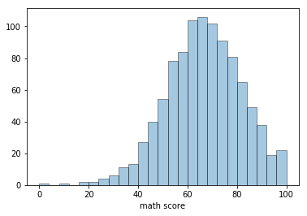

```python
sns.distplot(df['math score'],kde=False,hist_kws=dict(edgecolor='k',linewidth=1))
```

```python
print("Minimum math score in the data is:",df['math score'].min())
print("Maximum math score in the data is:",df['math score'].max())
print("Range of scores is from {} to {}, value is {}".format(df['math score'].min(),df['math score'].max(),df['math score'].max()-df['reading score'].min()))
print("Default bin is 50, so each bar corresponds to the value of:",(df['math score'].max()-df['math score'].min())/50)
```

```
Minimum math score in the data is: 0
Maximum math score in the data is: 100
Range of scores is from 0 to 100, value is 83
Default bin is 50, so each bar corresponds to the value of: 2.0
```

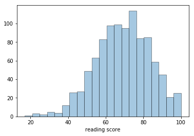

```python
sns.distplot(df['reading score'],kde=False,hist_kws=dict(edgecolor='k',linewidth=1))
```

```python
print("Minimum reading score in the data is:",df['reading score'].min())
print("Maximum reading score in the data is:",df['reading score'].max())
print("Range of scores is from {} to {}, value is {}".format(df['reading score'].min(),df['reading score'].max(),df['reading score'].max()-df['reading score'].min()))
print("Default bin is 50, so each bar corresponds to the value of:",(df['reading score'].max()-df['reading score'].min())/50)
```

```
Minimum reading score in the data is: 17
Maximum reading score in the data is: 100
Range of scores is from 17 to 100, value is 83
Default bin is 50, so each bar corresponds to the value of: 1.66
```

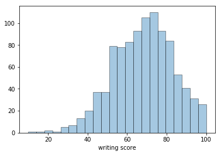

```python
sns.distplot(df['writing score'],kde=False,hist_kws=dict(edgecolor='k',linewidth=1))
```

```python
print("Minimum writing score in the data is:",df['writing score'].min())
print("Maximum writing score in the data is:",df['writing score'].max())
print("Range of scores is from {} to {}, value is {}".format(df['writing score'].min(),df['writing score'].max(),df['writing score'].max()-df['writing score'].min()))
print("Default bin is 50, so each bar corresponds to the value of:",(df['writing score'].max()-df['writing score'].min())/50)
```

```
Minimum writing score in the data is: 10
Maximum writing score in the data is: 100
Range of scores is from 10 to 100, value is 90
Default bin is 50, so each bar corresponds to the value of: 1.8
```

```python
df.head(10)
```

|  | gender | race/ethnicity | parental level of education | lunch | test preparation course | math score | reading score | writing score |
| --- | --- | --- | --- | --- | --- | --- | --- | --- |
| 0 | female | group B | bachelor's degree | standard | none | 72 | 72 | 74 |
| 1 | female | group C | some college | standard | completed | 69 | 90 | 88 |
| 2 | female | group B | master's degree | standard | none | 90 | 95 | 93 |
| 3 | male | group A | associate's degree | free/reduced | none | 47 | 57 | 44 |
| 4 | male | group C | some college | standard | none | 76 | 78 | 75 |
| 5 | female | group B | associate's degree | standard | none | 71 | 83 | 78 |
| 6 | female | group B | some college | standard | completed | 88 | 95 | 92 |
| 7 | male | group B | some college | free/reduced | none | 40 | 43 | 39 |
| 8 | male | group D | high school | free/reduced | completed | 64 | 64 | 67 |
| 9 | female | group B | high school | free/reduced | none | 38 | 60 | 50 |

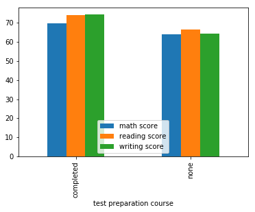

```python
df.groupby('test preparation course').mean().plot(kind='bar')
```

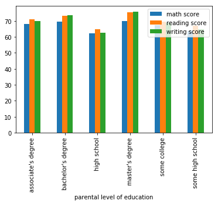

```python
df.groupby('parental level of education').mean().plot(kind='bar')
```

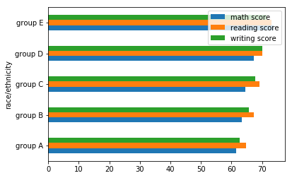

```python
df.groupby('race/ethnicity').mean().plot(kind='barh')
```

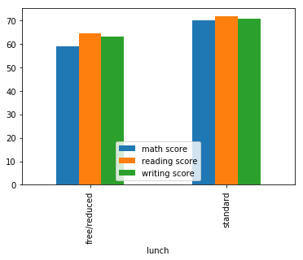

```python
df.groupby('lunch').mean().plot(kind='bar')
```

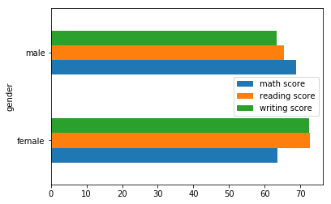

```python
df.groupby('gender').mean().plot(kind='barh')
```

```python
df['test preparation course'].value_counts()
```

```
none         642
completed    358
Name: test preparation course, dtype: int64
```

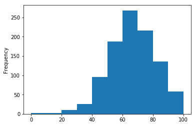

```python
df['math score'].plot(kind='hist')
```

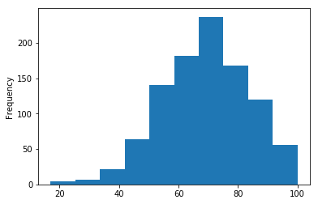

```python
df['reading score'].plot(kind='hist')
```

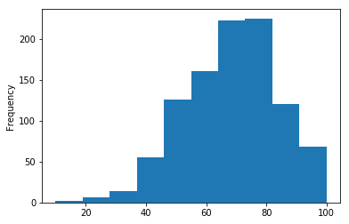

```python
df['writing score'].plot(kind='hist')
```

```python
df.dropna(how='any').shape
```

```
(1000, 8)
```

**No Null Values in this table so none of them are dropped**

```python
df.head()
```

|  | gender | race/ethnicity | parental level of education | lunch | test preparation course | math score | reading score | writing score |
| --- | --- | --- | --- | --- | --- | --- | --- | --- |
| 0 | female | group B | bachelor's degree | standard | none | 72 | 72 | 74 |
| 1 | female | group C | some college | standard | completed | 69 | 90 | 88 |
| 2 | female | group B | master's degree | standard | none | 90 | 95 | 93 |
| 3 | male | group A | associate's degree | free/reduced | none | 47 | 57 | 44 |
| 4 | male | group C | some college | standard | none | 76 | 78 | 75 |

```python
math_df = df.iloc[:,0:6]
```

```python
math_df.head()
```

|  | gender | race/ethnicity | parental level of education | lunch | test preparation course | math score |
| --- | --- | --- | --- | --- | --- | --- |
| 0 | female | group B | bachelor's degree | standard | none | 72 |
| 1 | female | group C | some college | standard | completed | 69 |
| 2 | female | group B | master's degree | standard | none | 90 |
| 3 | male | group A | associate's degree | free/reduced | none | 47 |
| 4 | male | group C | some college | standard | none | 76 |

```python
write_df = df.iloc[:,[0,1,2,3,4,7]]
```

```python
write_df.head()
```

|  | gender | race/ethnicity | parental level of education | lunch | test preparation course | writing score |
| --- | --- | --- | --- | --- | --- | --- |
| 0 | female | group B | bachelor's degree | standard | none | 74 |
| 1 | female | group C | some college | standard | completed | 88 |
| 2 | female | group B | master's degree | standard | none | 93 |
| 3 | male | group A | associate's degree | free/reduced | none | 44 |
| 4 | male | group C | some college | standard | none | 75 |

```python
read_df = df.iloc[:,[0,1,2,3,4,6]]
```

```python
read_df.head()
```

|  | gender | race/ethnicity | parental level of education | lunch | test preparation course | reading score |
| --- | --- | --- | --- | --- | --- | --- |
| 0 | female | group B | bachelor's degree | standard | none | 72 |
| 1 | female | group C | some college | standard | completed | 90 |
| 2 | female | group B | master's degree | standard | none | 95 |
| 3 | male | group A | associate's degree | free/reduced | none | 57 |
| 4 | male | group C | some college | standard | none | 78 |

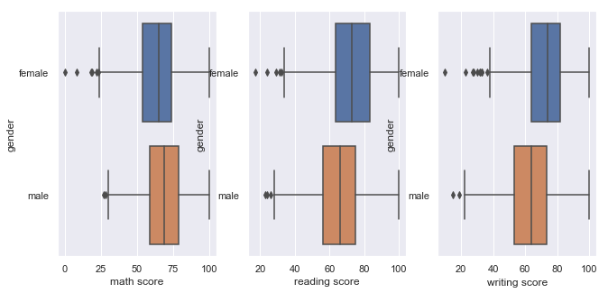

```python
sns.set(rc={'figure.figsize':(10.7,5)})
fig,ax = plt.subplots(1,3)
sns.boxplot(x='math score',y='gender',data=df,ax=ax[0])
sns.boxplot(x='reading score',y='gender',data=df,ax=ax[1])
sns.boxplot(x='writing score',y='gender',data=df,ax=ax[2])
```

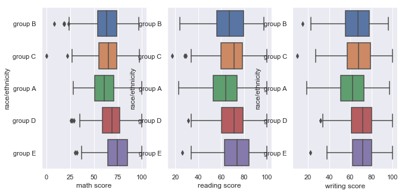

```python
fig,ax = plt.subplots(1,3)
sns.boxplot(x='math score',y='race/ethnicity',data=df,ax=ax[0])
sns.boxplot(x='reading score',y='race/ethnicity',data=df,ax=ax[1])
sns.boxplot(x='writing score',y='race/ethnicity',data=df,ax=ax[2])
```

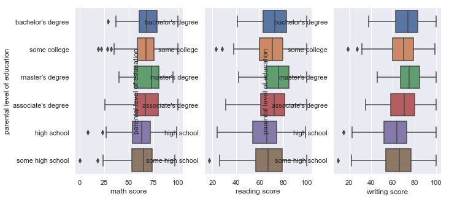

```python
fig,ax = plt.subplots(1,3)
sns.boxplot(x='math score',y='parental level of education',data=df,ax=ax[0])
sns.boxplot(x='reading score',y='parental level of education',data=df,ax=ax[1])
sns.boxplot(x='writing score',y='parental level of education',data=df,ax=ax[2])
```

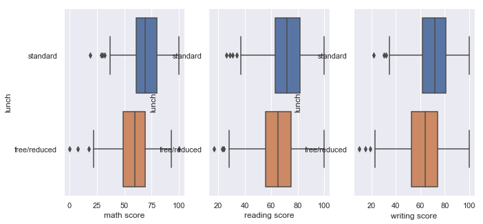

```python
fig,ax = plt.subplots(1,3)
sns.boxplot(x='math score',y='lunch',data=df,ax=ax[0])
sns.boxplot(x='reading score',y='lunch',data=df,ax=ax[1])
sns.boxplot(x='writing score',y='lunch',data=df,ax=ax[2])
```

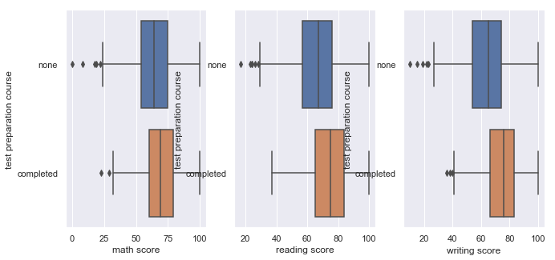

```python
fig,ax = plt.subplots(1,3)
sns.boxplot(x='math score',y='test preparation course',data=df,ax=ax[0])
sns.boxplot(x='reading score',y='test preparation course',data=df,ax=ax[1])
sns.boxplot(x='writing score',y='test preparation course',data=df,ax=ax[2])
```

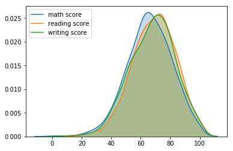

```python
sns.kdeplot(df['math score'],shade=True)
sns.kdeplot(df['reading score'],shade=True)
sns.kdeplot(df['writing score'],shade=True)
```

```python
Q1 = df['math score'].quantile(0.25)
Q3 = df['math score'].quantile(0.75)
IQR = Q3 - Q1    #IQR is interquartile range.

filter = (df['math score'] >= Q1 - 1.5 * IQR) & (df['math score'] <= Q3 + 1.5 *IQR)
df.loc[filter]
```

|  | gender | race/ethnicity | parental level of education | lunch | test preparation course | math score | reading score | writing score |
| --- | --- | --- | --- | --- | --- | --- | --- | --- |
| 0 | female | group B | bachelor's degree | standard | none | 72 | 72 | 74 |
| 1 | female | group C | some college | standard | completed | 69 | 90 | 88 |
| 2 | female | group B | master's degree | standard | none | 90 | 95 | 93 |
| 3 | male | group A | associate's degree | free/reduced | none | 47 | 57 | 44 |
| 4 | male | group C | some college | standard | none | 76 | 78 | 75 |
| 5 | female | group B | associate's degree | standard | none | 71 | 83 | 78 |
| 6 | female | group B | some college | standard | completed | 88 | 95 | 92 |
| 7 | male | group B | some college | free/reduced | none | 40 | 43 | 39 |
| 8 | male | group D | high school | free/reduced | completed | 64 | 64 | 67 |
| 9 | female | group B | high school | free/reduced | none | 38 | 60 | 50 |
| 10 | male | group C | associate's degree | standard | none | 58 | 54 | 52 |
| 11 | male | group D | associate's degree | standard | none | 40 | 52 | 43 |
| 12 | female | group B | high school | standard | none | 65 | 81 | 73 |
| 13 | male | group A | some college | standard | completed | 78 | 72 | 70 |
| 14 | female | group A | master's degree | standard | none | 50 | 53 | 58 |
| 15 | female | group C | some high school | standard | none | 69 | 75 | 78 |
| 16 | male | group C | high school | standard | none | 88 | 89 | 86 |
| 18 | male | group C | master's degree | free/reduced | completed | 46 | 42 | 46 |
| 19 | female | group C | associate's degree | free/reduced | none | 54 | 58 | 61 |
| 20 | male | group D | high school | standard | none | 66 | 69 | 63 |
| 21 | female | group B | some college | free/reduced | completed | 65 | 75 | 70 |
| 22 | male | group D | some college | standard | none | 44 | 54 | 53 |
| 23 | female | group C | some high school | standard | none | 69 | 73 | 73 |
| 24 | male | group D | bachelor's degree | free/reduced | completed | 74 | 71 | 80 |
| 25 | male | group A | master's degree | free/reduced | none | 73 | 74 | 72 |
| 26 | male | group B | some college | standard | none | 69 | 54 | 55 |
| 27 | female | group C | bachelor's degree | standard | none | 67 | 69 | 75 |
| 28 | male | group C | high school | standard | none | 70 | 70 | 65 |
| 29 | female | group D | master's degree | standard | none | 62 | 70 | 75 |
| 30 | female | group D | some college | standard | none | 69 | 74 | 74 |
| ... | ... | ... | ... | ... | ... | ... | ... | ... |
| 969 | female | group B | bachelor's degree | standard | none | 75 | 84 | 80 |
| 970 | female | group D | bachelor's degree | standard | none | 89 | 100 | 100 |
| 971 | male | group C | some high school | standard | completed | 78 | 72 | 69 |
| 972 | female | group A | high school | free/reduced | completed | 53 | 50 | 60 |
| 973 | female | group D | some college | free/reduced | none | 49 | 65 | 61 |
| 974 | female | group A | some college | standard | none | 54 | 63 | 67 |
| 975 | female | group C | some college | standard | completed | 64 | 82 | 77 |
| 976 | male | group B | some college | free/reduced | completed | 60 | 62 | 60 |
| 977 | male | group C | associate's degree | standard | none | 62 | 65 | 58 |
| 978 | male | group D | high school | standard | completed | 55 | 41 | 48 |
| 979 | female | group C | associate's degree | standard | none | 91 | 95 | 94 |
| 981 | male | group D | some high school | standard | none | 81 | 78 | 78 |
| 982 | male | group B | some high school | standard | completed | 79 | 85 | 86 |
| 983 | female | group A | some college | standard | completed | 78 | 87 | 91 |
| 984 | female | group C | some high school | standard | none | 74 | 75 | 82 |
| 985 | male | group A | high school | standard | none | 57 | 51 | 54 |
| 986 | female | group C | associate's degree | standard | none | 40 | 59 | 51 |
| 987 | male | group E | some high school | standard | completed | 81 | 75 | 76 |
| 988 | female | group A | some high school | free/reduced | none | 44 | 45 | 45 |
| 989 | female | group D | some college | free/reduced | completed | 67 | 86 | 83 |
| 990 | male | group E | high school | free/reduced | completed | 86 | 81 | 75 |
| 991 | female | group B | some high school | standard | completed | 65 | 82 | 78 |
| 992 | female | group D | associate's degree | free/reduced | none | 55 | 76 | 76 |
| 993 | female | group D | bachelor's degree | free/reduced | none | 62 | 72 | 74 |
| 994 | male | group A | high school | standard | none | 63 | 63 | 62 |
| 995 | female | group E | master's degree | standard | completed | 88 | 99 | 95 |
| 996 | male | group C | high school | free/reduced | none | 62 | 55 | 55 |
| 997 | female | group C | high school | free/reduced | completed | 59 | 71 | 65 |
| 998 | female | group D | some college | standard | completed | 68 | 78 | 77 |
| 999 | female | group D | some college | free/reduced | none | 77 | 86 | 86 |

992 rows × 8 columns

```python
Q1 = df['reading score'].quantile(0.25)
Q3 = df['reading score'].quantile(0.75)
IQR = Q3 - Q1    #IQR is interquartile range.

filter = (df['reading score'] >= Q1 - 1.5 * IQR) & (df['reading score'] <= Q3 + 1.5 *IQR)
df.loc[filter]
```

|  | gender | race/ethnicity | parental level of education | lunch | test preparation course | math score | reading score | writing score |
| --- | --- | --- | --- | --- | --- | --- | --- | --- |
| 0 | female | group B | bachelor's degree | standard | none | 72 | 72 | 74 |
| 1 | female | group C | some college | standard | completed | 69 | 90 | 88 |
| 2 | female | group B | master's degree | standard | none | 90 | 95 | 93 |
| 3 | male | group A | associate's degree | free/reduced | none | 47 | 57 | 44 |
| 4 | male | group C | some college | standard | none | 76 | 78 | 75 |
| 5 | female | group B | associate's degree | standard | none | 71 | 83 | 78 |
| 6 | female | group B | some college | standard | completed | 88 | 95 | 92 |
| 7 | male | group B | some college | free/reduced | none | 40 | 43 | 39 |
| 8 | male | group D | high school | free/reduced | completed | 64 | 64 | 67 |
| 9 | female | group B | high school | free/reduced | none | 38 | 60 | 50 |
| 10 | male | group C | associate's degree | standard | none | 58 | 54 | 52 |
| 11 | male | group D | associate's degree | standard | none | 40 | 52 | 43 |
| 12 | female | group B | high school | standard | none | 65 | 81 | 73 |
| 13 | male | group A | some college | standard | completed | 78 | 72 | 70 |
| 14 | female | group A | master's degree | standard | none | 50 | 53 | 58 |
| 15 | female | group C | some high school | standard | none | 69 | 75 | 78 |
| 16 | male | group C | high school | standard | none | 88 | 89 | 86 |
| 17 | female | group B | some high school | free/reduced | none | 18 | 32 | 28 |
| 18 | male | group C | master's degree | free/reduced | completed | 46 | 42 | 46 |
| 19 | female | group C | associate's degree | free/reduced | none | 54 | 58 | 61 |
| 20 | male | group D | high school | standard | none | 66 | 69 | 63 |
| 21 | female | group B | some college | free/reduced | completed | 65 | 75 | 70 |
| 22 | male | group D | some college | standard | none | 44 | 54 | 53 |
| 23 | female | group C | some high school | standard | none | 69 | 73 | 73 |
| 24 | male | group D | bachelor's degree | free/reduced | completed | 74 | 71 | 80 |
| 25 | male | group A | master's degree | free/reduced | none | 73 | 74 | 72 |
| 26 | male | group B | some college | standard | none | 69 | 54 | 55 |
| 27 | female | group C | bachelor's degree | standard | none | 67 | 69 | 75 |
| 28 | male | group C | high school | standard | none | 70 | 70 | 65 |
| 29 | female | group D | master's degree | standard | none | 62 | 70 | 75 |
| ... | ... | ... | ... | ... | ... | ... | ... | ... |
| 969 | female | group B | bachelor's degree | standard | none | 75 | 84 | 80 |
| 970 | female | group D | bachelor's degree | standard | none | 89 | 100 | 100 |
| 971 | male | group C | some high school | standard | completed | 78 | 72 | 69 |
| 972 | female | group A | high school | free/reduced | completed | 53 | 50 | 60 |
| 973 | female | group D | some college | free/reduced | none | 49 | 65 | 61 |
| 974 | female | group A | some college | standard | none | 54 | 63 | 67 |
| 975 | female | group C | some college | standard | completed | 64 | 82 | 77 |
| 976 | male | group B | some college | free/reduced | completed | 60 | 62 | 60 |
| 977 | male | group C | associate's degree | standard | none | 62 | 65 | 58 |
| 978 | male | group D | high school | standard | completed | 55 | 41 | 48 |
| 979 | female | group C | associate's degree | standard | none | 91 | 95 | 94 |
| 981 | male | group D | some high school | standard | none | 81 | 78 | 78 |
| 982 | male | group B | some high school | standard | completed | 79 | 85 | 86 |
| 983 | female | group A | some college | standard | completed | 78 | 87 | 91 |
| 984 | female | group C | some high school | standard | none | 74 | 75 | 82 |
| 985 | male | group A | high school | standard | none | 57 | 51 | 54 |
| 986 | female | group C | associate's degree | standard | none | 40 | 59 | 51 |
| 987 | male | group E | some high school | standard | completed | 81 | 75 | 76 |
| 988 | female | group A | some high school | free/reduced | none | 44 | 45 | 45 |
| 989 | female | group D | some college | free/reduced | completed | 67 | 86 | 83 |
| 990 | male | group E | high school | free/reduced | completed | 86 | 81 | 75 |
| 991 | female | group B | some high school | standard | completed | 65 | 82 | 78 |
| 992 | female | group D | associate's degree | free/reduced | none | 55 | 76 | 76 |
| 993 | female | group D | bachelor's degree | free/reduced | none | 62 | 72 | 74 |
| 994 | male | group A | high school | standard | none | 63 | 63 | 62 |
| 995 | female | group E | master's degree | standard | completed | 88 | 99 | 95 |
| 996 | male | group C | high school | free/reduced | none | 62 | 55 | 55 |
| 997 | female | group C | high school | free/reduced | completed | 59 | 71 | 65 |
| 998 | female | group D | some college | standard | completed | 68 | 78 | 77 |
| 999 | female | group D | some college | free/reduced | none | 77 | 86 | 86 |

994 rows × 8 columns

```python
Q1 = df['writing score'].quantile(0.25)
Q3 = df['writing score'].quantile(0.75)
IQR = Q3 - Q1    #IQR is interquartile range.

filter = (df['writing score'] >= Q1 - 1.5 * IQR) & (df['writing score'] <= Q3 + 1.5 *IQR)
df.loc[filter]
```

|  | gender | race/ethnicity | parental level of education | lunch | test preparation course | math score | reading score | writing score |
| --- | --- | --- | --- | --- | --- | --- | --- | --- |
| 0 | female | group B | bachelor's degree | standard | none | 72 | 72 | 74 |
| 1 | female | group C | some college | standard | completed | 69 | 90 | 88 |
| 2 | female | group B | master's degree | standard | none | 90 | 95 | 93 |
| 3 | male | group A | associate's degree | free/reduced | none | 47 | 57 | 44 |
| 4 | male | group C | some college | standard | none | 76 | 78 | 75 |
| 5 | female | group B | associate's degree | standard | none | 71 | 83 | 78 |
| 6 | female | group B | some college | standard | completed | 88 | 95 | 92 |
| 7 | male | group B | some college | free/reduced | none | 40 | 43 | 39 |
| 8 | male | group D | high school | free/reduced | completed | 64 | 64 | 67 |
| 9 | female | group B | high school | free/reduced | none | 38 | 60 | 50 |
| 10 | male | group C | associate's degree | standard | none | 58 | 54 | 52 |
| 11 | male | group D | associate's degree | standard | none | 40 | 52 | 43 |
| 12 | female | group B | high school | standard | none | 65 | 81 | 73 |
| 13 | male | group A | some college | standard | completed | 78 | 72 | 70 |
| 14 | female | group A | master's degree | standard | none | 50 | 53 | 58 |
| 15 | female | group C | some high school | standard | none | 69 | 75 | 78 |
| 16 | male | group C | high school | standard | none | 88 | 89 | 86 |
| 17 | female | group B | some high school | free/reduced | none | 18 | 32 | 28 |
| 18 | male | group C | master's degree | free/reduced | completed | 46 | 42 | 46 |
| 19 | female | group C | associate's degree | free/reduced | none | 54 | 58 | 61 |
| 20 | male | group D | high school | standard | none | 66 | 69 | 63 |
| 21 | female | group B | some college | free/reduced | completed | 65 | 75 | 70 |
| 22 | male | group D | some college | standard | none | 44 | 54 | 53 |
| 23 | female | group C | some high school | standard | none | 69 | 73 | 73 |
| 24 | male | group D | bachelor's degree | free/reduced | completed | 74 | 71 | 80 |
| 25 | male | group A | master's degree | free/reduced | none | 73 | 74 | 72 |
| 26 | male | group B | some college | standard | none | 69 | 54 | 55 |
| 27 | female | group C | bachelor's degree | standard | none | 67 | 69 | 75 |
| 28 | male | group C | high school | standard | none | 70 | 70 | 65 |
| 29 | female | group D | master's degree | standard | none | 62 | 70 | 75 |
| ... | ... | ... | ... | ... | ... | ... | ... | ... |
| 969 | female | group B | bachelor's degree | standard | none | 75 | 84 | 80 |
| 970 | female | group D | bachelor's degree | standard | none | 89 | 100 | 100 |
| 971 | male | group C | some high school | standard | completed | 78 | 72 | 69 |
| 972 | female | group A | high school | free/reduced | completed | 53 | 50 | 60 |
| 973 | female | group D | some college | free/reduced | none | 49 | 65 | 61 |
| 974 | female | group A | some college | standard | none | 54 | 63 | 67 |
| 975 | female | group C | some college | standard | completed | 64 | 82 | 77 |
| 976 | male | group B | some college | free/reduced | completed | 60 | 62 | 60 |
| 977 | male | group C | associate's degree | standard | none | 62 | 65 | 58 |
| 978 | male | group D | high school | standard | completed | 55 | 41 | 48 |
| 979 | female | group C | associate's degree | standard | none | 91 | 95 | 94 |
| 981 | male | group D | some high school | standard | none | 81 | 78 | 78 |
| 982 | male | group B | some high school | standard | completed | 79 | 85 | 86 |
| 983 | female | group A | some college | standard | completed | 78 | 87 | 91 |
| 984 | female | group C | some high school | standard | none | 74 | 75 | 82 |
| 985 | male | group A | high school | standard | none | 57 | 51 | 54 |
| 986 | female | group C | associate's degree | standard | none | 40 | 59 | 51 |
| 987 | male | group E | some high school | standard | completed | 81 | 75 | 76 |
| 988 | female | group A | some high school | free/reduced | none | 44 | 45 | 45 |
| 989 | female | group D | some college | free/reduced | completed | 67 | 86 | 83 |
| 990 | male | group E | high school | free/reduced | completed | 86 | 81 | 75 |
| 991 | female | group B | some high school | standard | completed | 65 | 82 | 78 |
| 992 | female | group D | associate's degree | free/reduced | none | 55 | 76 | 76 |
| 993 | female | group D | bachelor's degree | free/reduced | none | 62 | 72 | 74 |
| 994 | male | group A | high school | standard | none | 63 | 63 | 62 |
| 995 | female | group E | master's degree | standard | completed | 88 | 99 | 95 |
| 996 | male | group C | high school | free/reduced | none | 62 | 55 | 55 |
| 997 | female | group C | high school | free/reduced | completed | 59 | 71 | 65 |
| 998 | female | group D | some college | standard | completed | 68 | 78 | 77 |
| 999 | female | group D | some college | free/reduced | none | 77 | 86 | 86 |

995 rows × 8 columns

**Analysis of Data**

Minimum writing score in the data is: 10 Maximum writing score in the data is: 100 Range of scores is from 10 to 100, value is 90

Minimum reading score in the data is: 17 Maximum reading score in the data is: 100 Range of scores is from 17 to 100, value is 83

Mean : Math Score 66.08900, Reading Score 69.169000,Writing Score 68.054000

**Anomalies in Data**

Outliers exists in marks

Boxplot helped in detecting Anomalies in the Data 8 outliers in math score 5 outliers in writing score 6 outliers in reading score

**No Null Values in the Data**

Box Plot furthur gives insights about range of data and dependence of marks on the categorical data

Box plot is the most preffered method for establishing relationships between categorical data and continous values.